# EN3160 Assignment 1

## Intensity Transformations and Neighborhood Filtering

# Question 1: Intensity Transformation

The image intensity is mapped with a piecewise-linear transformation using the breakpoints `(0,0), (50,50), (100,150), (150,255), (255,255)`. The transformation curve, original image, transformed image, and an alternative breakpoint experiment are shown below.

```python
import cv2; import numpy as np; import matplotlib.pyplot as plt; from pathlib import Path; plt.rcParams["figure.figsize"] = (8, 4); plt.rcParams["figure.dpi"] = 80
```

```python
def intensity_transform(im, breakpoints):
    """
    Apply piecewise-linear intensity transformation.
    im:
        Grayscale image with values in [0,255]
    breakpoints:
        List/array of [input, output] points
    """
    breakpoints = np.array(breakpoints, dtype=np.float32)
    x = breakpoints[:, 0]
    y = breakpoints[:, 1]
    # Create lookup table
    lut = np.interp(np.arange(256), x, y)
    # Apply LUT
    output = cv2.LUT(im, lut.astype(np.uint8))
    return output
```

```python
img = cv2.imread("emma.jpg", cv2.IMREAD_GRAYSCALE)
if img is None:
    raise FileNotFoundError("Could not find einstein.jpg")
```

```python
breakpoints = [
    [0, 0],
    [50, 50],
    [100, 150],
    [150, 255],
    [255, 255]
]
transformed = intensity_transform(img, breakpoints)
```

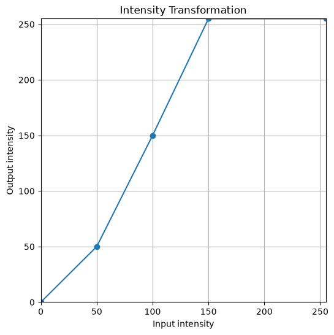

```python
bp = np.array(breakpoints); plt.figure(figsize=(5, 5)); plt.plot(bp[:, 0], bp[:, 1], marker='o'); plt.xlabel("Input intensity"); plt.ylabel("Output intensity"); plt.title("Intensity Transformation"); plt.xlim(0, 255); plt.ylim(0, 255); plt.grid(); plt.show()
```

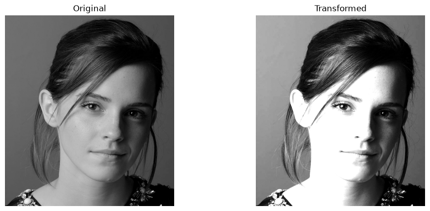

```python
plt.figure(figsize=(8, 3.5)); plt.subplot(1, 2, 1); plt.imshow(img, cmap="gray"); plt.title("Original"); plt.axis("off"); plt.subplot(1, 2, 2); plt.imshow(transformed, cmap="gray"); plt.title("Transformed"); plt.axis("off"); plt.show()
```

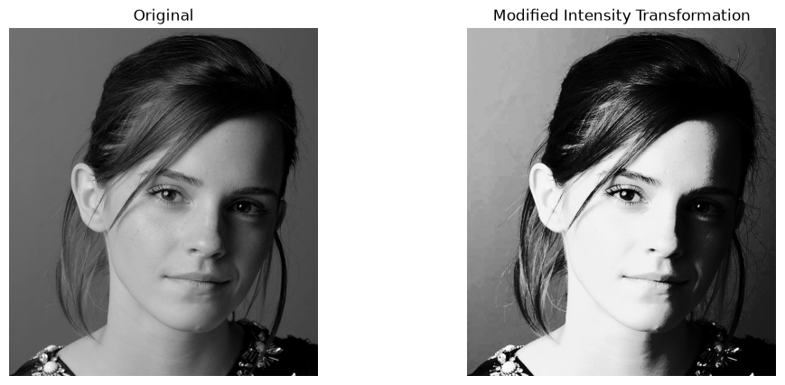

```python
breakpoints2 = [[0, 0], [70, 30], [110, 180], [180, 240], [255, 255]]; transformed2 = intensity_transform(img, breakpoints2); plt.figure(figsize=(8, 3.5)); plt.subplot(1, 2, 1); plt.imshow(img, cmap="gray"); plt.title("Original"); plt.axis("off"); plt.subplot(1, 2, 2); plt.imshow(transformed2, cmap="gray"); plt.title("Modified Intensity Transformation"); plt.axis("off"); plt.show()
```

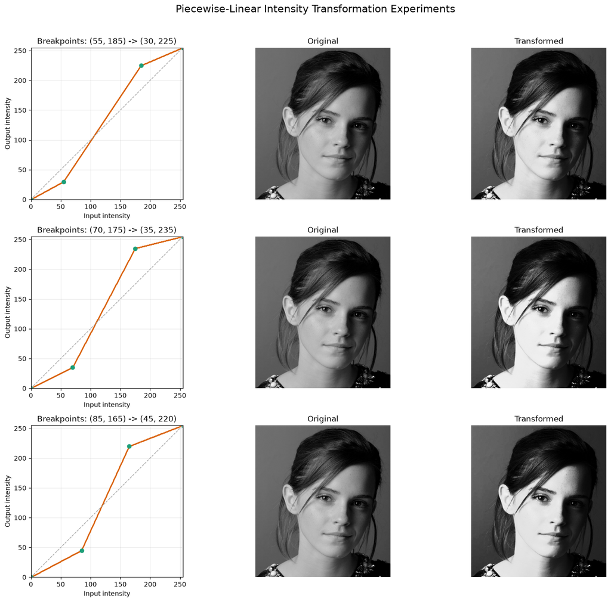

```python
# Compare several piecewise-linear intensity transformations
import cv2
import numpy as np
import matplotlib.pyplot as plt
if img.ndim == 3: gray = cv2.cvtColor(img, cv2.COLOR_BGR2GRAY)
else: gray = img.copy()
gray = np.asarray(gray, dtype=np.uint8)
experiments = [(55, 185, 30, 225), (70, 175, 35, 235), (85, 165, 45, 220)]
intensities = np.arange(256)
fig, axes = plt.subplots(len(experiments), 3, figsize=(10, 7))
fig.suptitle("Piecewise-Linear Intensity Transformation Experiments", fontsize=14, y=0.995)
for row, (r1, r2, s1, s2) in enumerate(experiments):
    input_points = [0, r1, r2, 255]; output_points = [0, s1, s2, 255]; mapping = np.interp(intensities, input_points, output_points).astype(np.uint8); result = cv2.LUT(gray, mapping)
    axes[row, 0].plot(intensities, mapping, color="#d95f02", linewidth=2); axes[row, 0].plot(input_points, output_points, "o", color="#1b9e77"); axes[row, 0].plot([0, 255], [0, 255], "--", color="0.65", linewidth=1); axes[row, 0].set_title(f"Breakpoints: ({r1}, {r2}) -> ({s1}, {s2})"); axes[row, 0].set_xlabel("Input intensity"); axes[row, 0].set_ylabel("Output intensity"); axes[row, 0].set_xlim(0, 255); axes[row, 0].set_ylim(0, 255); axes[row, 0].set_aspect("equal"); axes[row, 0].grid(alpha=0.25)
    axes[row, 1].imshow(gray, cmap="gray", vmin=0, vmax=255); axes[row, 1].set_title("Original"); axes[row, 1].axis("off")
    axes[row, 2].imshow(result, cmap="gray", vmin=0, vmax=255); axes[row, 2].set_title("Transformed"); axes[row, 2].axis("off")
plt.tight_layout(rect=(0, 0, 1, 0.98)); plt.show()
```

# Question 2: White Matter and Gray Matter

The brain proton-density image is enhanced with two mappings. The white-matter mapping suppresses darker intensities and expands brighter tissue, while the gray-matter mapping emphasizes the middle intensity range. The corresponding transformation curves and output images are shown below.

```python
brain = cv2.imread("images/q2.jpeg", cv2.IMREAD_GRAYSCALE)
if brain is None:
    raise FileNotFoundError("Could not find images/q2.jpeg")
```

```python
white_breakpoints = [
    [0, 0],
    [80, 0],
    [120, 180],
    [180, 255],
    [255, 255]
]
gray_breakpoints = [
    [0, 0],
    [60, 80],
    [130, 220],
    [200, 255],
    [255, 255]
]
white_matter = intensity_transform(brain, white_breakpoints)
gray_matter = intensity_transform(brain, gray_breakpoints)
```

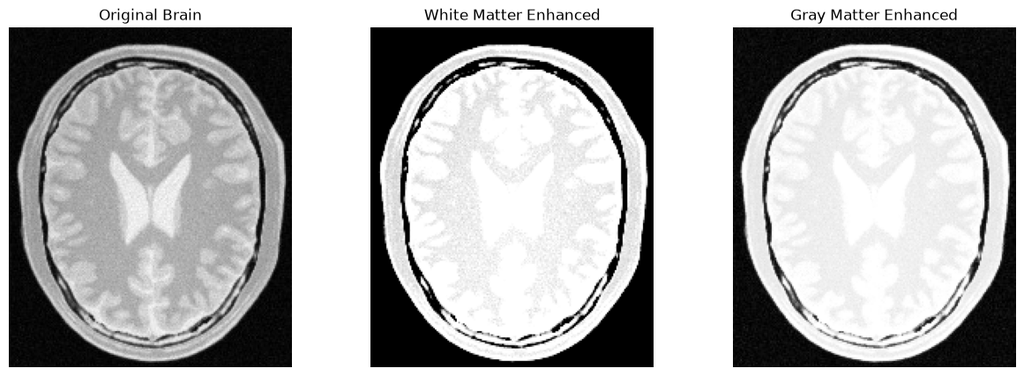

```python
plt.figure(figsize=(9, 3.5)); plt.subplot(1, 3, 1); plt.imshow(brain, cmap="gray"); plt.title("Original Brain"); plt.axis("off"); plt.subplot(1, 3, 2); plt.imshow(white_matter, cmap="gray"); plt.title("White Matter Enhanced"); plt.axis("off"); plt.subplot(1, 3, 3); plt.imshow(gray_matter, cmap="gray"); plt.title("Gray Matter Enhanced"); plt.axis("off"); plt.show()
```

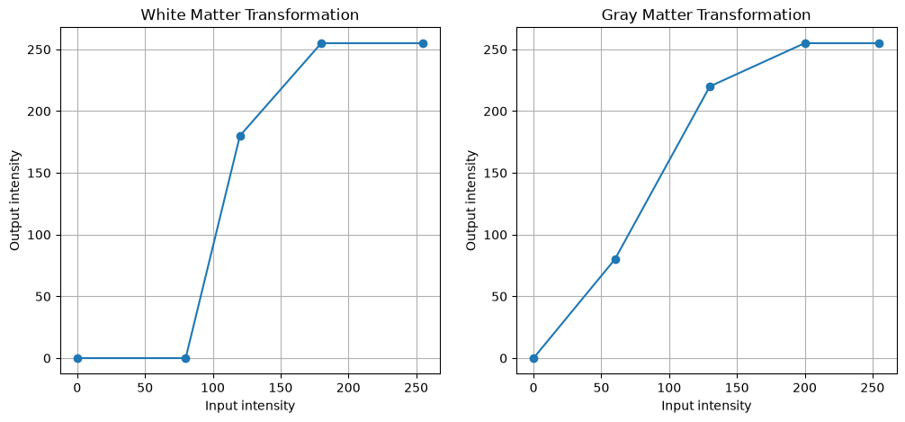

```python
plt.figure(figsize=(8, 3.5)); plt.subplot(1, 2, 1); bp = np.array(white_breakpoints); plt.plot(bp[:, 0], bp[:, 1], marker='o'); plt.title("White Matter Transformation"); plt.xlabel("Input intensity"); plt.ylabel("Output intensity"); plt.grid(); plt.subplot(1, 2, 2); bp = np.array(gray_breakpoints); plt.plot(bp[:, 0], bp[:, 1], marker='o'); plt.title("Gray Matter Transformation"); plt.xlabel("Input intensity"); plt.ylabel("Output intensity"); plt.grid(); plt.show()
```

# Question 3: Gamma Correction in L*a*b* Colour Space

Gamma correction is applied only to the L channel using `gamma = 0.7`. A value below one expands darker luminance values and brightens the image. The corrected image and original/corrected L-plane histograms are compared.

```python
img = cv2.imread("images/WhatsApp Image 2026-09-09 at 20.02.44 (1).jpeg")
if img is None:
    raise FileNotFoundError("Could not find images/WhatsApp Image 2026-09-09 at 20.02.44 (1).jpeg")
img_rgb = cv2.cvtColor(img, cv2.COLOR_BGR2RGB)
lab = cv2.cvtColor(img, cv2.COLOR_BGR2LAB)
L, A, B = cv2.split(lab)
print("L range:", L.min(), L.max())
```

```
L range: 0 255
```

```python
gamma = 0.7; L_normalized = L.astype(np.float32) / 255.0; L_gamma = np.power(L_normalized, gamma); L_corrected = np.uint8(L_gamma * 255)
```

```python
lab_corrected = cv2.merge([L_corrected, A, B])
corrected = cv2.cvtColor(
    lab_corrected,
    cv2.COLOR_LAB2RGB
)
```

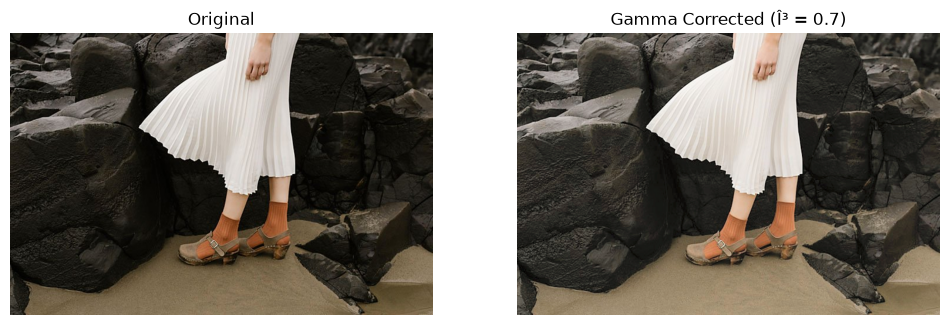

```python
plt.figure(figsize=(8, 3.5)); plt.subplot(1, 2, 1); plt.imshow(img_rgb); plt.title("Original"); plt.axis("off"); plt.subplot(1, 2, 2); plt.imshow(corrected); plt.title(f"Gamma Corrected (ÃŽÂ³ = {gamma})"); plt.axis("off"); plt.show()
```

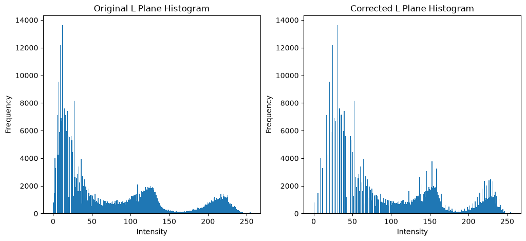

```python
plt.figure(figsize=(8, 3.5)); plt.subplot(1, 2, 1); plt.hist(L.flatten(), bins=256, range=(0, 255)); plt.title("Original L Plane Histogram"); plt.xlabel("Intensity"); plt.ylabel("Frequency"); plt.subplot(1, 2, 2); plt.hist(L_corrected.flatten(), bins=256, range=(0, 255)); plt.title("Corrected L Plane Histogram"); plt.xlabel("Intensity"); plt.ylabel("Frequency"); plt.show()
```

# Question 4: Vibrance Enhancement

The image is converted to HSV and the saturation plane is transformed with `sigma = 70` and `a = 0.8`. Hue and value remain unchanged, so the operation increases colour richness while preserving the image structure. The original image, enhanced image, and transformation curve are displayed.

```python
img = cv2.imread("images/WhatsApp Image 2026-09-09 at 20.02.441.jpeg")
if img is None:
    raise FileNotFoundError("Could not find images/WhatsApp Image 2026-09-09 at 20.02.441.jpeg")
hsv = cv2.cvtColor(img, cv2.COLOR_BGR2HSV)
H, S, V = cv2.split(hsv)
```

[figure not shown]

```python
plt.figure(figsize=(9, 3.5)); plt.subplot(1, 3, 1); plt.imshow(H, cmap="gray"); plt.title("Hue"); plt.axis("off"); plt.subplot(1, 3, 2); plt.imshow(S, cmap="gray"); plt.title("Saturation"); plt.axis("off"); plt.subplot(1, 3, 3); plt.imshow(V, cmap="gray"); plt.title("Value"); plt.axis("off"); plt.show()
```

```python
sigma = 70
a = 0.8
x = np.arange(256, dtype=np.float32)
increase = a * 128 * np.exp(
    -((x - 128) ** 2) / (2 * sigma ** 2)
)
transformation = np.minimum(x + increase, 255)
```

```python
S_float = S.astype(np.float32)
S_enhanced = np.interp(
    S_float,
    x,
    transformation
).astype(np.uint8)
```

```python
hsv_enhanced = cv2.merge([H, S_enhanced, V])
enhanced = cv2.cvtColor(
    hsv_enhanced,
    cv2.COLOR_HSV2RGB
)
original_rgb = cv2.cvtColor(
    img,
    cv2.COLOR_BGR2RGB
)
```

[figure not shown]

```python
plt.figure(figsize=(9, 3.5)); plt.subplot(1, 3, 1); plt.imshow(original_rgb); plt.title("Original"); plt.axis("off"); plt.subplot(1, 3, 2); plt.imshow(enhanced); plt.title(f"Vibrance Enhanced (a = {a})"); plt.axis("off"); plt.subplot(1, 3, 3); plt.plot(x, transformation); plt.xlabel("Input Saturation"); plt.ylabel("Output Saturation"); plt.title("Vibrance Transformation"); plt.grid(); plt.show()
```

[figure not shown]

```python
a_values = [0.3, 0.5, 0.8, 1.0]
plt.figure(figsize=(9, 5))
for i, a_test in enumerate(a_values):
    increase = a_test * 128 * np.exp(
        -((x - 128) ** 2) / (2 * sigma ** 2)
    )
    transform = np.minimum(x + increase, 255)
    S_test = np.interp(
        S.astype(np.float32),
        x,
        transform
    ).astype(np.uint8)
    hsv_test = cv2.merge([H, S_test, V])
    result = cv2.cvtColor(hsv_test, cv2.COLOR_HSV2RGB)
    plt.subplot(2, 2, i + 1)
    plt.imshow(result)
    plt.title(f"a = {a_test}")
    plt.axis("off")
plt.show()
```

# Question 5: Histogram Equalization

A histogram, cumulative distribution function, and lookup table are used to implement histogram equalization manually. The result should spread a concentrated intensity range and improve image contrast.

```python
def histogram_equalization(im):
    """
    Histogram equalization implemented manually.
    """
    # Histogram
    hist = np.bincount(
        im.flatten(),
        minlength=256
    )
    # Cumulative histogram
    cdf = np.cumsum(hist)
    # Find first non-zero CDF
    cdf_min = cdf[cdf > 0][0]
    # Number of pixels
    total_pixels = im.size
    # Histogram equalization mapping
    lut = np.round(
        (cdf - cdf_min) /
        (total_pixels - cdf_min) * 255
    )
    lut = np.clip(lut, 0, 255).astype(np.uint8)
    # Apply LUT
    equalized = lut[im]
    return equalized
```

```python
img = cv2.imread("images/shells.tif", cv2.IMREAD_GRAYSCALE)
if img is None:
    raise FileNotFoundError("Could not find images/shells.tif")
```

```python
equalized = histogram_equalization(img)
```

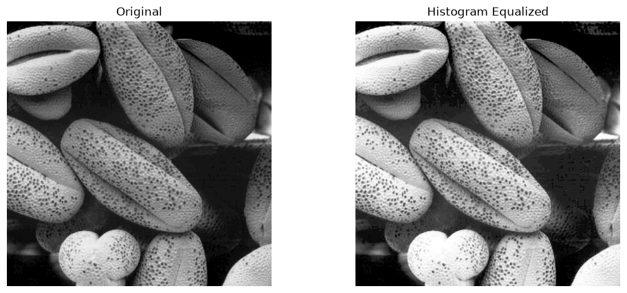

```python
plt.figure(figsize=(8, 3.5)); plt.subplot(1, 2, 1); plt.imshow(img, cmap="gray"); plt.title("Original"); plt.axis("off"); plt.subplot(1, 2, 2); plt.imshow(equalized, cmap="gray"); plt.title("Histogram Equalized"); plt.axis("off"); plt.show()
```

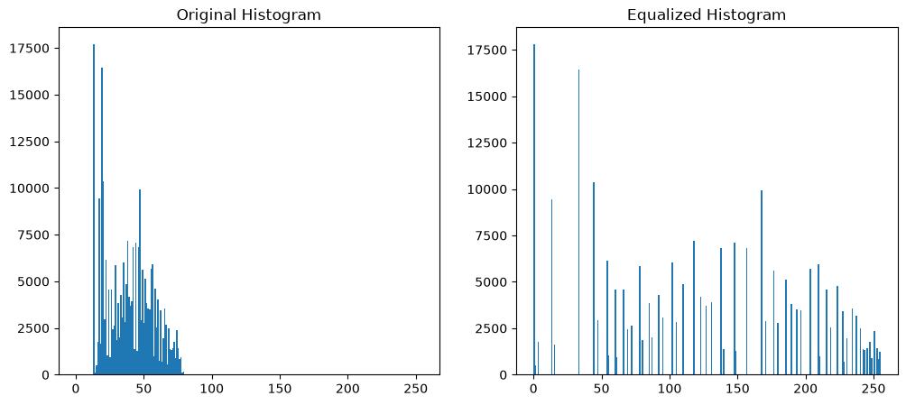

```python
plt.figure(figsize=(8, 3.5)); plt.subplot(1, 2, 1); plt.hist(img.flatten(), bins=256, range=(0, 255)); plt.title("Original Histogram"); plt.subplot(1, 2, 2); plt.hist(equalized.flatten(), bins=256, range=(0, 255)); plt.title("Equalized Histogram"); plt.show()
```

# Question 6: Foreground Histogram Equalization

The HSV planes are inspected and the saturation plane is thresholded to create a binary foreground mask. Histogram equalization is applied only to foreground pixels in the value plane, then the equalized foreground is recombined with the unchanged background.

```python
img = cv2.imread("images/WhatsApp Image 2026-09-09 at 20.02.44 (2).jpeg")
if img is None:
    raise FileNotFoundError("Could not find images/WhatsApp Image 2026-09-09 at 20.02.44 (2).jpeg")
hsv = cv2.cvtColor(img, cv2.COLOR_BGR2HSV)
H, S, V = cv2.split(hsv)
```

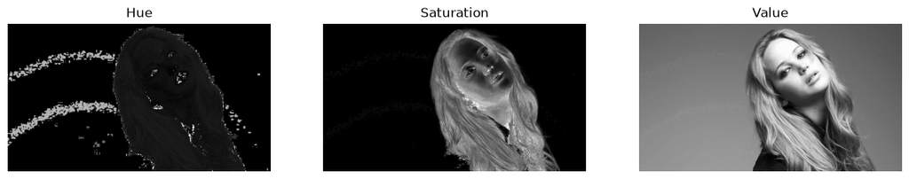

```python
plt.figure(figsize=(9, 3.5)); plt.subplot(1, 3, 1); plt.imshow(H, cmap="gray"); plt.title("Hue"); plt.axis("off"); plt.subplot(1, 3, 2); plt.imshow(S, cmap="gray"); plt.title("Saturation"); plt.axis("off"); plt.subplot(1, 3, 3); plt.imshow(V, cmap="gray"); plt.title("Value"); plt.axis("off"); plt.show()
```

```python
threshold = 50
_, mask = cv2.threshold(
    S,
    threshold,
    255,
    cv2.THRESH_BINARY
)
```

```python
threshold = 50
_, mask = cv2.threshold(
    S,
    threshold,
    255,
    cv2.THRESH_BINARY
)
```

```python
kernel = np.ones((5, 5), np.uint8)
mask = cv2.morphologyEx(
    mask,
    cv2.MORPH_OPEN,
    kernel
)
mask = cv2.morphologyEx(
    mask,
    cv2.MORPH_CLOSE,
    kernel
)
```

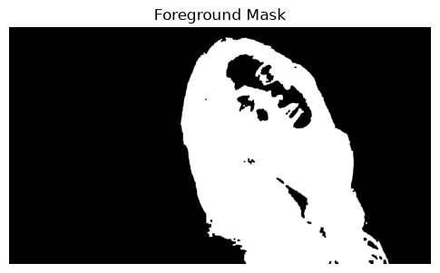

```python
plt.figure(figsize=(6, 5)); plt.imshow(mask, cmap="gray"); plt.title("Foreground Mask"); plt.axis("off"); plt.show()
```

```python
foreground = cv2.bitwise_and(
    img,
    img,
    mask=mask
)
```

```python
foreground_V = cv2.bitwise_and(
    V,
    V,
    mask=mask
)
hist = np.bincount(
    foreground_V[mask > 0],
    minlength=256
)
cdf = np.cumsum(hist)
cdf_min = cdf[cdf > 0][0]
num_foreground_pixels = np.count_nonzero(mask)
lut = np.round(
    (cdf - cdf_min) /
    (num_foreground_pixels - cdf_min) * 255
)
lut = np.clip(lut, 0, 255).astype(np.uint8)
```

```python
V_equalized = V.copy()
V_equalized[mask > 0] = lut[
    V[mask > 0]
]
```

```python
background_mask = cv2.bitwise_not(mask)
background = cv2.bitwise_and(
    img,
    img,
    mask=background_mask
)
```

```python
hsv_result = cv2.merge([
    H,
    S,
    V_equalized
])
result = cv2.cvtColor(
    hsv_result,
    cv2.COLOR_HSV2BGR
)
```

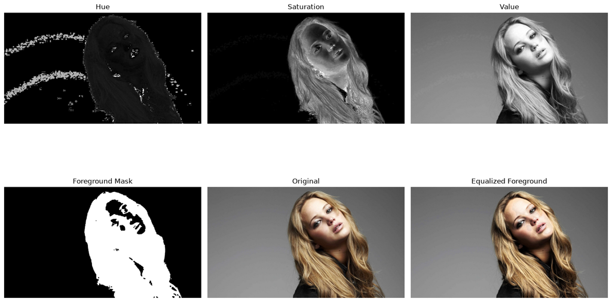

```python
plt.figure(figsize=(9, 6)); plt.subplot(2, 3, 1); plt.imshow(H, cmap="gray"); plt.title("Hue"); plt.axis("off"); plt.subplot(2, 3, 2); plt.imshow(S, cmap="gray"); plt.title("Saturation"); plt.axis("off"); plt.subplot(2, 3, 3); plt.imshow(V, cmap="gray"); plt.title("Value"); plt.axis("off"); plt.subplot(2, 3, 4); plt.imshow(mask, cmap="gray"); plt.title("Foreground Mask"); plt.axis("off"); plt.subplot(2, 3, 5); plt.imshow(cv2.cvtColor(img, cv2.COLOR_BGR2RGB)); plt.title("Original"); plt.axis("off"); plt.subplot(2, 3, 6); plt.imshow(cv2.cvtColor(result, cv2.COLOR_BGR2RGB)); plt.title("Equalized Foreground"); plt.axis("off"); plt.tight_layout(); plt.show()
```

# Question 7: Sobel Filtering

The image gradients are computed with OpenCV `filter2D`, a manual convolution implementation, and separable one-dimensional kernels. The gradient magnitude highlights edges, while the maximum differences test agreement between the manual and separable implementations.

```python
img = cv2.imread(
    "images/WhatsApp Image 2026-09-09 at 20.02.43 (2).jpeg",
    cv2.IMREAD_GRAYSCALE
)
```

```python
sobel_x_kernel = np.array([
    [-1, 0, 1],
    [-2, 0, 2],
    [-1, 0, 1]
], dtype=np.float32)
sobel_y_kernel = np.array([
    [-1, -2, -1],
    [0, 0, 0],
    [1, 2, 1]
], dtype=np.float32)
```

```python
gx = cv2.filter2D(
    img,
    cv2.CV_64F,
    sobel_x_kernel
)
gy = cv2.filter2D(
    img,
    cv2.CV_64F,
    sobel_y_kernel
)
magnitude = np.sqrt(
    gx ** 2 + gy ** 2
)
magnitude = cv2.normalize(
    magnitude,
    None,
    0,
    255,
    cv2.NORM_MINMAX
).astype(np.uint8)
```

[figure not shown]

```python
plt.figure(figsize=(9, 3.5)); plt.subplot(1, 3, 1); plt.imshow(np.abs(gx), cmap="gray"); plt.title("Sobel X"); plt.axis("off"); plt.subplot(1, 3, 2); plt.imshow(np.abs(gy), cmap="gray"); plt.title("Sobel Y"); plt.axis("off"); plt.subplot(1, 3, 3); plt.imshow(magnitude, cmap="gray"); plt.title("Gradient Magnitude"); plt.axis("off"); plt.show()
```

[figure not shown]

```python
plt.figure(figsize=(9, 3.5)); plt.subplot(1, 3, 1); plt.imshow(np.abs(gx), cmap="gray"); plt.title("Sobel X"); plt.axis("off"); plt.subplot(1, 3, 2); plt.imshow(np.abs(gy), cmap="gray"); plt.title("Sobel Y"); plt.axis("off"); plt.subplot(1, 3, 3); plt.imshow(magnitude, cmap="gray"); plt.title("Gradient Magnitude"); plt.axis("off"); plt.show()
```

```python
def my_filter2D(im, kernel):
    """
    Manual 2D convolution.
    """
    kh, kw = kernel.shape
    pad_h = kh // 2
    pad_w = kw // 2
    padded = np.pad(
        im,
        ((pad_h, pad_h),
         (pad_w, pad_w)),
        mode="constant"
    )
    output = np.zeros(
        im.shape,
        dtype=np.float64
    )
    for i in range(im.shape[0]):
        for j in range(im.shape[1]):
            region = padded[
                i:i+kh,
                j:j+kw
            ]
            output[i, j] = np.sum(
                region * kernel
            )
    return output
```

```python
gx_manual = my_filter2D(
    img,
    sobel_x_kernel
)
gy_manual = my_filter2D(
    img,
    sobel_y_kernel
)
magnitude_manual = np.sqrt(
    gx_manual ** 2 +
    gy_manual ** 2
)
magnitude_manual = cv2.normalize(
    magnitude_manual,
    None,
    0,
    255,
    cv2.NORM_MINMAX
).astype(np.uint8)
```

```python
kernel_vertical = np.array([
    [1],
    [2],
    [1]
], dtype=np.float64)
kernel_horizontal = np.array([
    [1, 0, -1]
], dtype=np.float64)
```

```python
temp = my_filter2D(
    img,
    kernel_vertical
)
gx_separable = my_filter2D(
    temp,
    kernel_horizontal
)
```

```python
kernel_horizontal_y = np.array([
    [1, 2, 1]
], dtype=np.float64)
kernel_vertical_y = np.array([
    [1],
    [0],
    [-1]
], dtype=np.float64)
temp = my_filter2D(
    img,
    kernel_horizontal_y
)
gy_separable = my_filter2D(
    temp,
    kernel_vertical_y
)
```

```python
difference_x = np.abs(
    gx_manual - gx_separable
)
difference_y = np.abs(
    gy_manual - gy_separable
)
print("Maximum X difference:", difference_x.max())
print("Maximum Y difference:", difference_y.max())
```

```
Maximum X difference: 1524.0
Maximum Y difference: 1980.0
```

# Question 8: Image Zooming

Nearest-neighbour and bilinear interpolation enlarge the small test image by a factor of four. Normalized SSD compares each enlarged result with the corresponding large original; a lower value indicates closer reconstruction.

```python
def zoom_nearest(im, scale):
    h, w = im.shape[:2]
    new_h = int(h * scale)
    new_w = int(w * scale)
    output = np.zeros(
        (new_h, new_w, *im.shape[2:]),
        dtype=im.dtype
    )
    for y in range(new_h):
        for x in range(new_w):
            src_y = int(y / scale)
            src_x = int(x / scale)
            src_y = min(src_y, h - 1)
            src_x = min(src_x, w - 1)
            output[y, x] = im[src_y, src_x]
    return output
```

```python
def zoom_bilinear(im, scale):
    h, w = im.shape[:2]
    new_h = int(h * scale)
    new_w = int(w * scale)
    if im.ndim == 2:
        output = np.zeros(
            (new_h, new_w),
            dtype=np.float32
        )
    else:
        output = np.zeros(
            (new_h, new_w, im.shape[2]),
            dtype=np.float32
        )
    for y in range(new_h):
        src_y = y / scale
        y0 = int(np.floor(src_y))
        y1 = min(y0 + 1, h - 1)
        dy = src_y - y0
        for x in range(new_w):
            src_x = x / scale
            x0 = int(np.floor(src_x))
            x1 = min(x0 + 1, w - 1)
            dx = src_x - x0
            top = (
                (1 - dx) * im[y0, x0] +
                dx * im[y0, x1]
            )
            bottom = (
                (1 - dx) * im[y1, x0] +
                dx * im[y1, x1]
            )
            output[y, x] = (
                (1 - dy) * top +
                dy * bottom
            )
    return np.clip(
        output,
        0,
        255
    ).astype(im.dtype)
```

```python
small = cv2.imread(
    "images/im01small.png",
    cv2.IMREAD_GRAYSCALE
)
nearest = zoom_nearest(
    small,
    4
)
bilinear = zoom_bilinear(
    small,
    4
)
```

```python
def normalized_ssd(im1, im2):
    im1 = im1.astype(np.float64)
    im2 = im2.astype(np.float64)
    ssd = np.sum(
        (im1 - im2) ** 2
    )
    normalized = ssd / im1.size
    return normalized
```

```python
original = cv2.imread(
    "images/im01.png",
    cv2.IMREAD_GRAYSCALE
)
ssd_nearest = normalized_ssd(
    original,
    nearest
)
ssd_bilinear = normalized_ssd(
    original,
    bilinear
)
print("Nearest-neighbor normalized SSD:",
      ssd_nearest)
print("Bilinear normalized SSD:",
      ssd_bilinear)
```

```
Nearest-neighbor normalized SSD: 137.2095703125
Bilinear normalized SSD: 201.4493962191358
```

[figure not shown]

```python
plt.figure(figsize=(9, 3.5)); plt.subplot(1, 3, 1); plt.imshow(small, cmap="gray"); plt.title("Small Image"); plt.axis("off"); plt.subplot(1, 3, 2); plt.imshow(nearest, cmap="gray"); plt.title("Nearest Neighbor"); plt.axis("off"); plt.subplot(1, 3, 3); plt.imshow(bilinear, cmap="gray"); plt.title("Bilinear"); plt.axis("off"); plt.show()
```